# Statistical models for source attribution of zoonotic diseases

10 December 2019

## Manawatu sentinel surveillance site

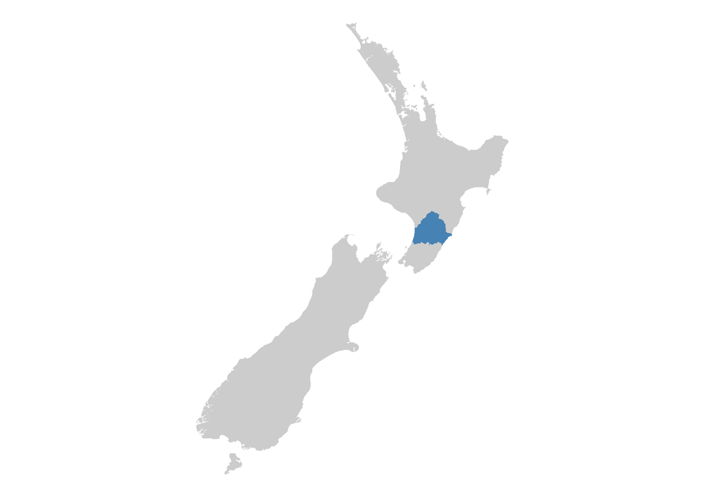

## Manawatu campylobacteriosis cases

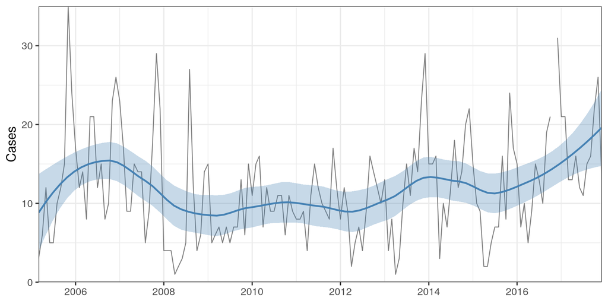

## New Zealand campylobacteriosis cases

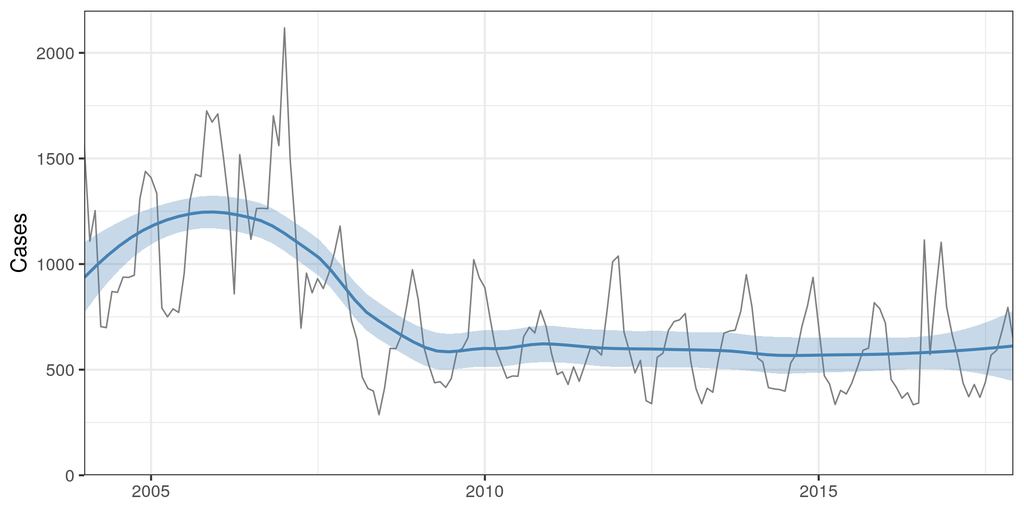

## MLST distribution of human cases

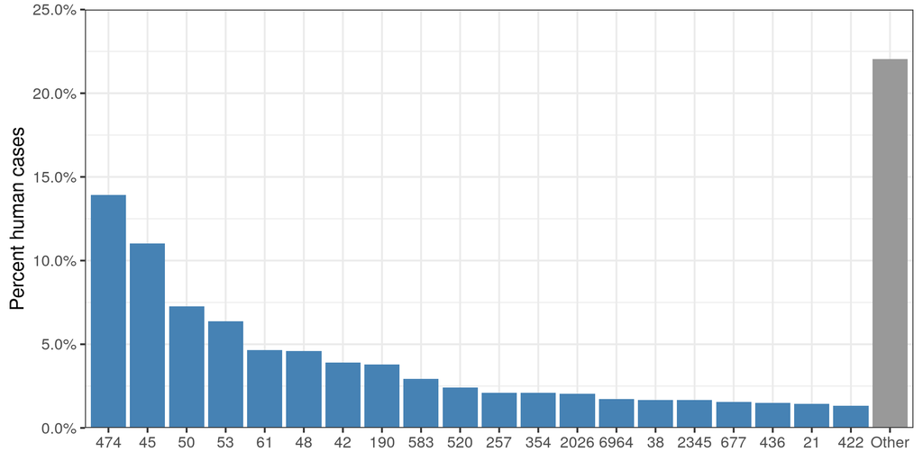

## MLSTs are source specific

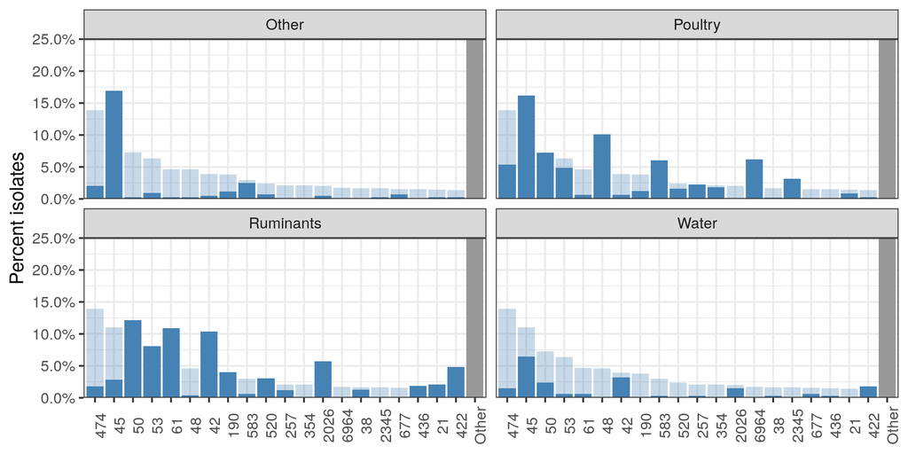

## Modelling

### R package islandR

## islandR model

\[ P(\mathsf{Human~cases}) = \prod_h P(\mathsf{st}_h) \]

## islandR model

\[ P(\mathsf{st}_h) = \sum_j P(\mathsf{st}_h~\mathsf{from~source}_j) P(\mathsf{source}_j) \]

## islandR model

\[ P(\mathsf{st}_h) = \sum_j \underbrace{P(\mathsf{st}_h~\mathsf{from~source}_j)}_\text{genomic model} P(\mathsf{source}_j) \]

## islandR model

\[ P(\mathsf{st}) = \sum_j \underbrace{P(\mathsf{st}_h~\mathsf{from~source}_j)}_\text{genomic model} \underbrace{P(\mathsf{source}_j)}_\text{attribution to source} \]

## MLSTs differ by rurality

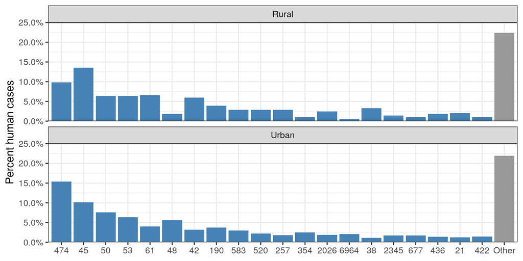

## Human cases by age and rurality

| Area | Under 5 | 5 and over | Unknown | Total |
| --- | --- | --- | --- | --- |
| Highly rural/remote area | 7 | 12 | 3 | 22 |
| Rural area with low urban influence | 34 | 102 | 17 | 153 |
| Rural area with moderate urban influence | 38 | 128 | 27 | 193 |
| Rural area with high urban influence | 14 | 90 | 16 | 120 |
| Independent Urban Area | 22 | 260 | 57 | 339 |
| Satellite Urban Area | 24 | 206 | 35 | 265 |
| Main urban area | 73 | 540 | 164 | 777 |
| Total | 212 | 1338 | 319 | 1869 |

## islandR model

\[ P(\mathsf{st}_h \mid \underbrace{t, \mathbf{x}_h}_\text{covariates}) = \sum_j \underbrace{P(\mathsf{st}_h~\mathsf{from~source}_j)}_\text{genomic model} \underbrace{P(\mathsf{source}_j \mid t, \mathbf{x})}_\text{attribution with covariates} \]

## islandR genomic models

- Asymmetric Island model (Wilson et al 2009)
- Dirichlet model (Liao et al 2019)

## Aymmetric Island model

### D. Wilson (2009)

Assume that genotypes arise from two or more homogeneous mixing populations where we have

- **Mutation**, where novel alleles are produced.
- **Recombination**, where the allele at a given locus has been observed before, but not in this allelic profile (i.e. the alleles come from at least two different genotypes).
- **Migration** between sources, where genotypes have been observed previously.

## Mutation

| ST | aspA | glnA | gltA | glyA | pgm | txt | uncA |
| --- | --- | --- | --- | --- | --- | --- | --- |
| 474 | 2 | 4 | 1 | 2 | 2 | 1 | 5 |
| ? | 2 | 4 | 1 | 2 | 29 | 1 | 5 |

- We have a novel allele at the pgm locus.
- We assume this genotype has arisen through **mutation**.

## Recombination

| ST | aspA | glnA | gltA | glyA | pgm | txt | uncA |
| --- | --- | --- | --- | --- | --- | --- | --- |
| 474 | 2 | 4 | 1 | 2 | 2 | 1 | 5 |
| ? | 2 | 4 | 1 | 2 | 1 | 1 | 5 |
| 45 | 4 | 7 | 10 | 4 | 1 | 7 | 1 |
| 3718 | 2 | 4 | 1 | 4 | 1 | 1 | 5 |

- We have seen this pgm allele before, but haven’t seen this genotype.
- We assume it arose through **recombination**, either from 45 or 3718.

## Migration

| ST | aspA | glnA | gltA | glyA | pgm | txt | uncA |
| --- | --- | --- | --- | --- | --- | --- | --- |
| 474 | 2 | 4 | 1 | 2 | 2 | 1 | 5 |
| ? | 2 | 4 | 1 | 2 | 2 | 1 | 5 |

- This is just 474. We’ve seen it before, but possibly not on this source.
- We assume it arose through **migration**.

## Asymmetric Island model

We model \(P(\mathsf{st}_h~\mathsf{from~source}_j)\) via:

\[ P(\mathsf{st}_h \mid j,X) = \sum_{c\in X} \frac{M_{S_cj}}{N_{S_c}} \prod_{l=1}^7 \left\{\begin{array}{ll} \mu_j & \text{if $\mathsf{st}_h^{l}$ is novel,}\\ (1-\mu_j)R_j\sum_{k=1}^J M_{kj}f^l_{\mathsf{st}_h^lk} & \text{if $\mathsf{st}_h^{l}\neq c^l$}\\ (1-\mu_j)\left[1 - R_j(1 - \sum_{k=1}^J M_{kj}f^l_{\mathsf{st}_h^lk})\right] & \text{if $\mathsf{st}_h^{l}=c^l$} \end{array} \right. \]

- \(c \in X\) are candidate sequences from which \(\mathsf{st}_h\) evolved (all sequences other than \(\mathsf{st}_h\)).
- \(S_c\) is the source where candidate sequence \(c\) was observed.
- \(N_{S_c}\) is the number of types observed on source \(S_c\).
- \(\mu_j\) be the probability of a novel mutant allele from source \(j\).
- \(R_j\) be the probability that a type has undergone recombination in source \(j\).
- \(M_{kj}\) be the probability of an allele migrating from source \(k\) to \(j\).
- \(f^l_{ak}\) be the frequency with which allele \(a\) has been observed at locus \(l\) in those genotypes sampled from source \(k\).

## Asymmetric Island model

The unknown parameters are

- The mutation probabilities \(\mu_j\)
- Recombination probabilities \(R_j\)
- Migration probabilities \(M_{jk}\).

The model is fit in a Bayesian context - we add Dirichlet priors to \(M_{jk}\) and Beta priors to \(\mu_j\) and \(R_j\).

Once we have these estimated, we can use all source sequences as candidates and estimate \(P(\mathsf{st}_h~\mathsf{given~source}_j)\) for the observed human sequences (even those unobserved on the sources).

## Dirichlet model

### S.J. Liao 2019

We model the observed count \(X_{ij}\) of type \(i\) on source \(j\) using a multinomial distribution:

\[ \mathbf{X}_{j} \sim \mathsf{Multinomial}(n_j, \mathbf{\pi}_j) \]

where \(n_j\) is the total number of isolates observed from source \(j\) and \(\mathbf{\pi}_j\) is the true proportion of each type on source \(j\). This may include types not observed on this source.

We then add prior information of observing each type on each source via a Dirichlet distribution, typically with each type being equally likely: \[ \mathbf{\pi}_{j} \sim \mathsf{Dirichlet}(\mathbf{1}) \]

## Dirichlet model

The posterior distribution for the true proportions \(\mathbf{\pi}_j\) of each type on source \(j\) is then also a Dirichlet distribution:

\[ \mathbf{\pi}_{j} \sim \mathsf{Dirichlet}(\mathbf{X}_j + \mathbf{1}) \] So we can fit this model really easily just by random sampling from a Dirichlet distribution.

## Genotype distributions

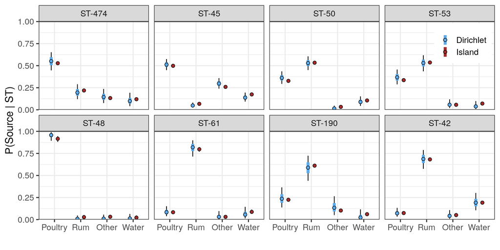

## Genotype distributions

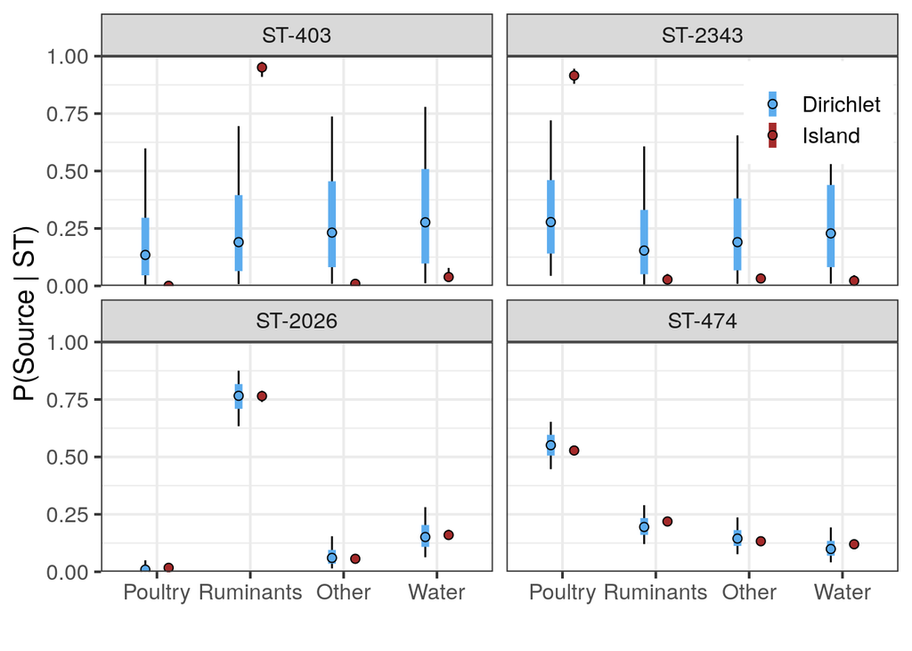

## islandR attribution

Within each source \(j\) we have a linear model on the logit scale for attribution: \[ \begin{aligned} \eta_{jh} &= \alpha_j + \beta_{j1} z_{1h} + \cdots + \beta_{jp} z_{ph}\\ p_{jh} &= \frac{\exp(\eta_{hj})}{\sum_j \exp(\eta_{hj})} \end{aligned} \]

The covariates can then be anything we like for each human case, and there’s a separate attribution probability for each unique covariate pattern in the data.

## Covariates: Rurality and Age

We’ll present four different covariate models:

- Rurality as 7 separate categories.
- Rurality as a linear trend (on logit scale).
- Separate linear trends for rurality pre/post 2008 poultry industry intervention.
- Separate linear trends for under 5 versus older than 5 years old (2008 onwards).

## Results

## Urban/Rural scales

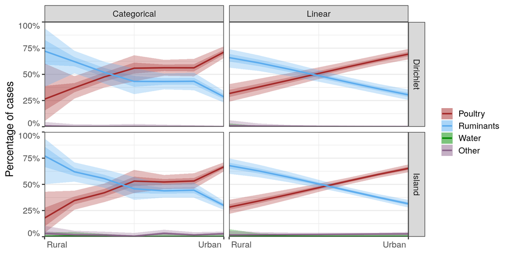

## Poultry industry intervention in 2008

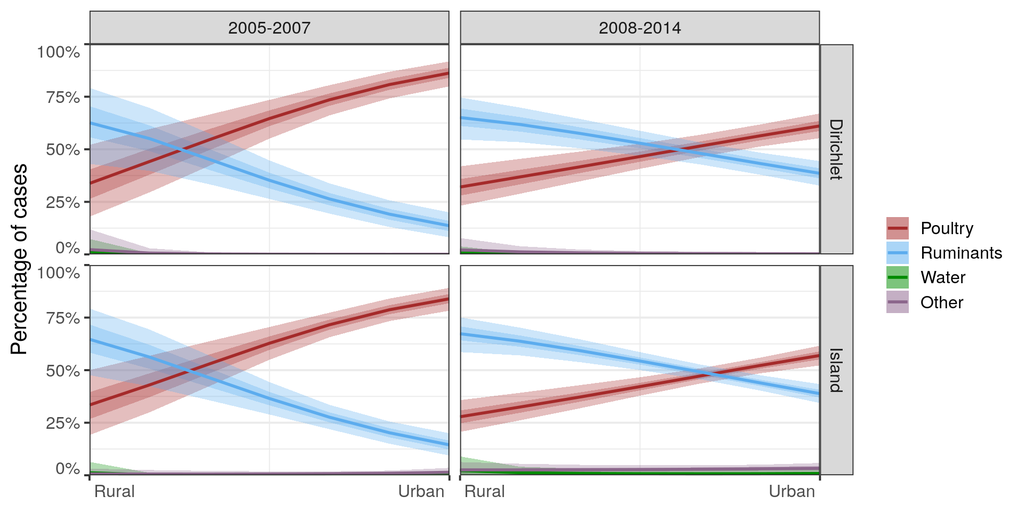

## Post 2008: Young kids

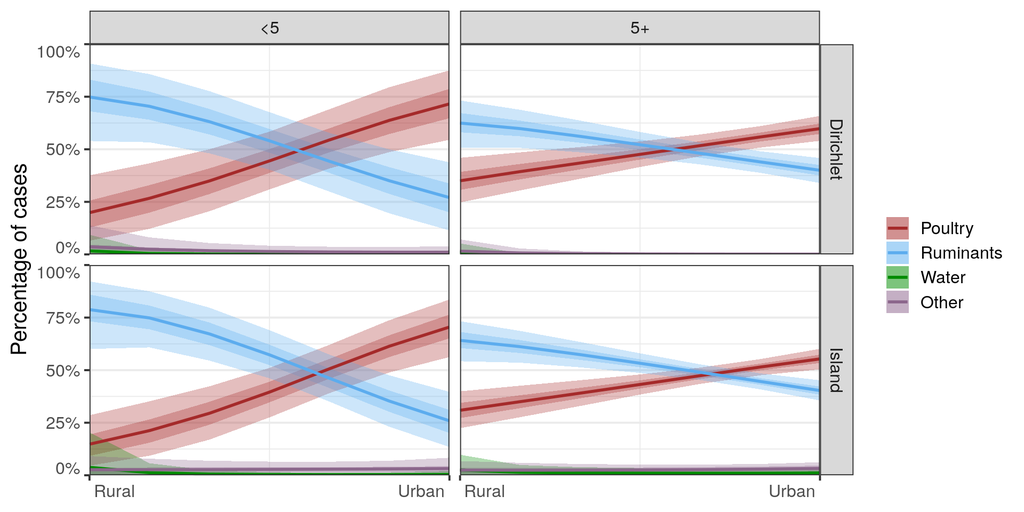

## Summary

- The Island model can assign genotypes not observed on the sources where the simple Dirichlet model has no information. But few cases are of this type.
- The simple Dirichlet model seems to do just as well as the Island model.
- With higher genomic precision, the Dirichlet model will lose ability to discriminate, as every human type will differ from source types.
- The Island model in theory will still work with higher genomic precision, but does the statistical model still hold?

## Summary

- Urban cases tend to be more associated with poultry, and rural cases with ruminants.
- A linear relationship between attribution and rurality seems adequate.
- Strong evidence of the intervention in the poultry industry reducing the burden from poultry.
- Strong evidence that kids under 5 in rural areas are more likely to have ruminant associated campylobacteriosis compared to over 5’s.

## Acknowledgements

- Sih-Jing Liao, Nigel French, Martin Hazelton
- **MidCentral Public Health Services**
- **Medlab Central**
- **ESR**: Phil Carter
- **mEpiLab**: Rukhshana Akhter, Julie Collins-Emerson,  
  Ahmed Fayaz, Anne Midwinter, Sarah Moore, Antoine Nohra,  
  Angie Reynolds, Lynn Rogers
- **Ministry for Primary Industries**: Donald Campbell,  
  Peter van der Logt

[figure not shown]

Twitter: [@jmarshallnz](https://twitter.com/jmarshallnz)

Github: jmarshallnz

**Thanks for listening!**

[figure not shown]

## Urban attribution

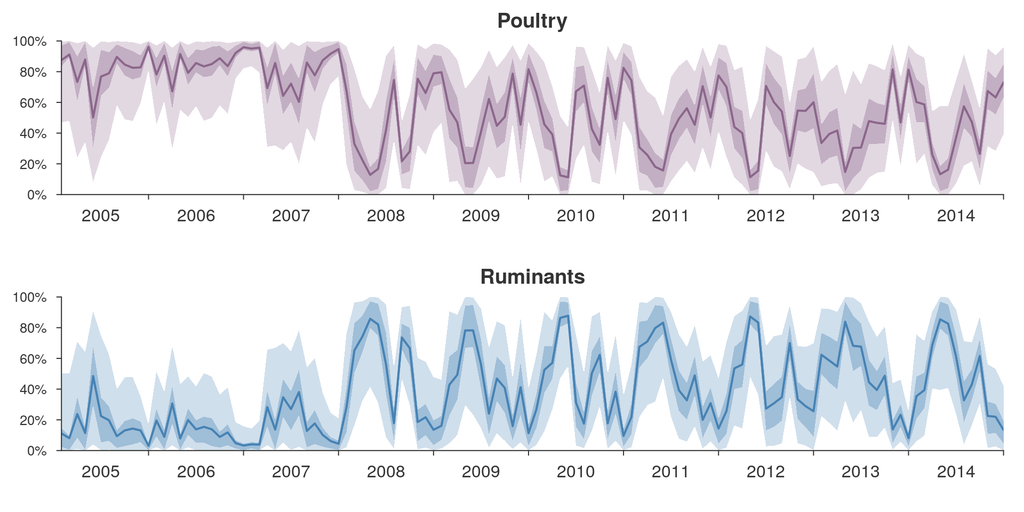

## Rural attribution

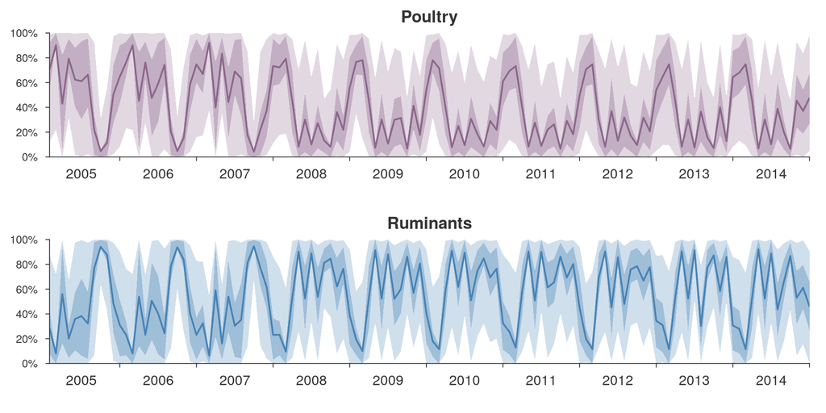

## Urban attribution

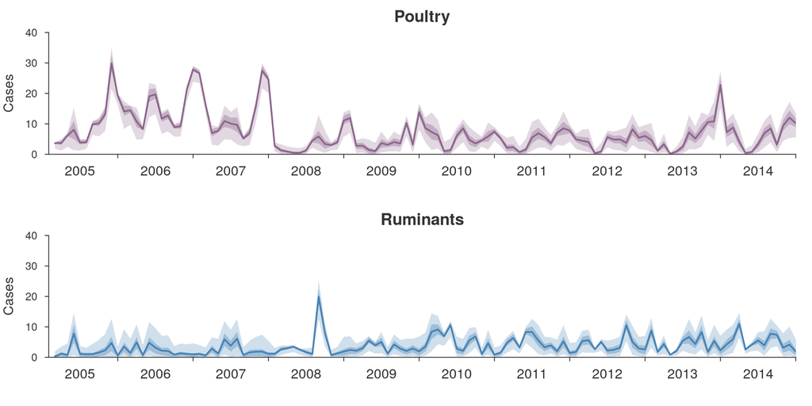

## Rural attribution

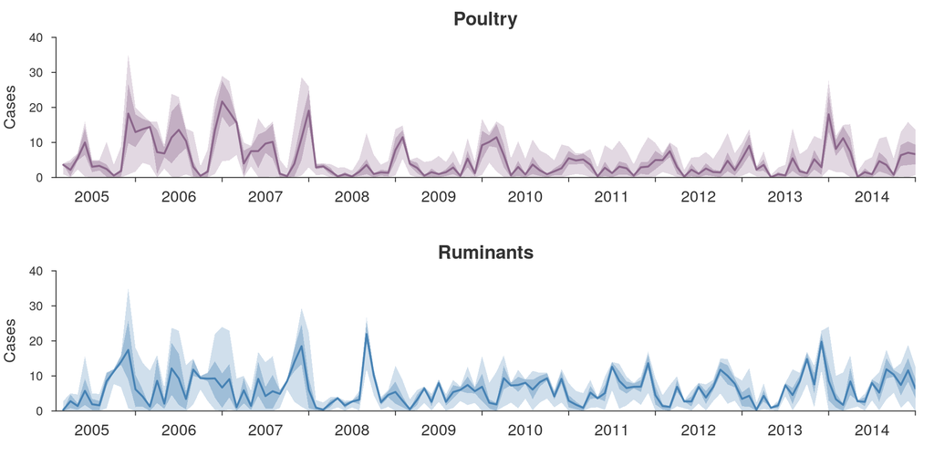

## Urban water/other attribution

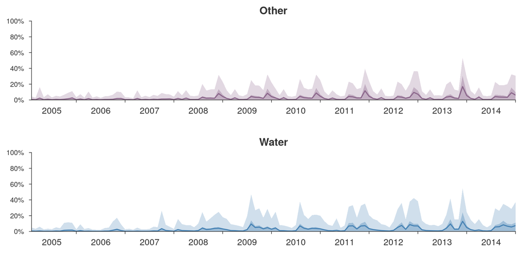

## Rural water/other attribution

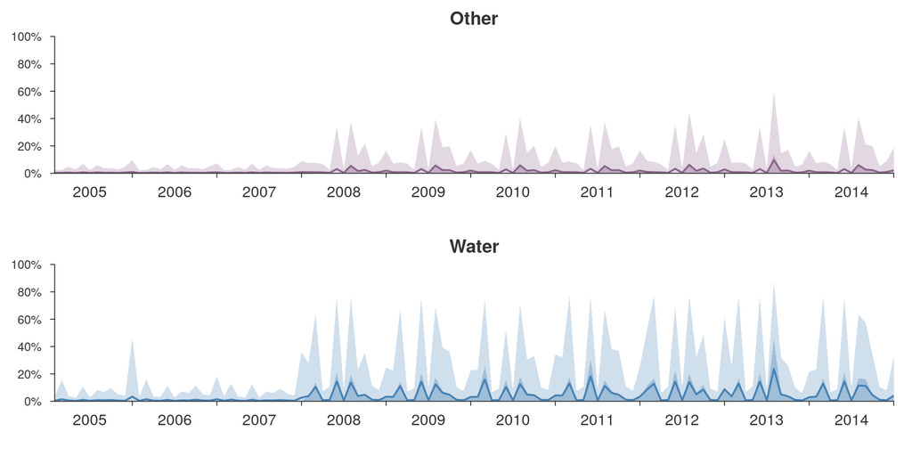

## Urban water/other attribution

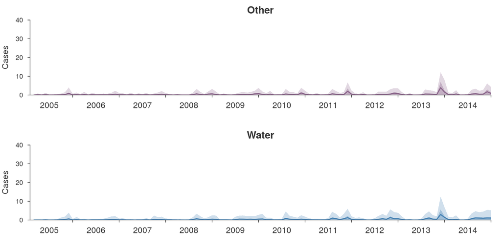

## Rural water/other attribution

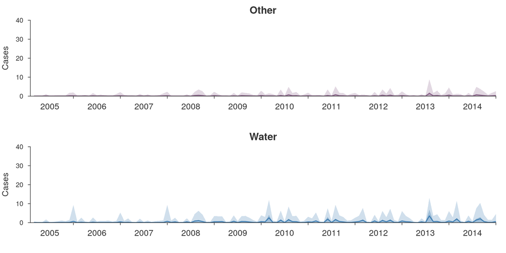